# Cyclistic Bike-Share Case Study

Deepa Subramani

2025-09-08

# Introduction

This case study analyzes how **Cyclistic**, a Chicago-based bike-share company, can convert casual riders into annual members.  
We will explore differences in usage patterns between casual riders and annual members using Cyclistic’s trip data.

# Business Task

The business task is to determine:  
**How do annual members and casual riders use Cyclistic bikes differently?**

This analysis will guide marketing strategies aimed at increasing annual memberships.

# Prepare

Key considerations:  
- Data is reliable and public.  
- Personally identifiable information (PII) is excluded for privacy.

```r
# Example: Load CSV files
trip_data <- read.csv("Divvy_Trips_2020_Q1.csv")

# Inspect data
glimpse(trip_data)
```

```
## Rows: 426,887
## Columns: 13
## $ ride_id            <chr> "EACB19130B0CDA4A", "8FED874C809DC021", "789F3C21E4…
## $ rideable_type      <chr> "docked_bike", "docked_bike", "docked_bike", "docke…
## $ started_at         <chr> "2020-01-21 20:06:59", "2020-01-30 14:22:39", "2020…
## $ ended_at           <chr> "2020-01-21 20:14:30", "2020-01-30 14:26:22", "2020…
## $ start_station_name <chr> "Western Ave & Leland Ave", "Clark St & Montrose Av…
## $ start_station_id   <int> 239, 234, 296, 51, 66, 212, 96, 96, 212, 38, 117, 1…
## $ end_station_name   <chr> "Clark St & Leland Ave", "Southport Ave & Irving Pa…
## $ end_station_id     <int> 326, 318, 117, 24, 212, 96, 212, 212, 96, 100, 632,…
## $ start_lat          <dbl> 41.9665, 41.9616, 41.9401, 41.8846, 41.8856, 41.889…
## $ start_lng          <dbl> -87.6884, -87.6660, -87.6455, -87.6319, -87.6418, -…
## $ end_lat            <dbl> 41.9671, 41.9542, 41.9402, 41.8918, 41.8899, 41.884…
## $ end_lng            <dbl> -87.6674, -87.6644, -87.6530, -87.6206, -87.6343, -…
## $ member_casual      <chr> "member", "member", "member", "member", "member", "…
```

```r
# Standardize column names
colnames(trip_data)
```

```
##  [1] "ride_id"            "rideable_type"      "started_at"
##  [4] "ended_at"           "start_station_name" "start_station_id"
##  [7] "end_station_name"   "end_station_id"     "start_lat"
## [10] "start_lng"          "end_lat"            "end_lng"
## [13] "member_casual"
```

```r
# Convert started_at and ended_at to datetime
trip_data <- trip_data %>% mutate(started_at = ymd_hms(started_at) , ended_at = ymd_hms(ended_at))

# create new calculated fields for ride duration and days of the trip

trip_data <- trip_data %>% mutate(ride_length =as.numeric(difftime(ended_at, started_at, units = "mins")),day_of_week = wday(started_at, label = TRUE))

# Remove bad data ex : 1) no missing date 2) remove rides <1 min or >24 hrs

trip_data_clean <- trip_data %>%
  filter(!is.na(started_at) & !is.na(ended_at)) %>%
  filter(ride_length > 1 & ride_length < 1440) %>% distinct()


# Save cleaned data into CSV

write_csv(trip_data_clean , "cyclistic_data_cleaned")
```

### Analyze

```r
# 1. Average ride length by rider type
avg_ride_length <- trip_data_clean %>%
  group_by(member_casual) %>%
  summarise(avg_duration = mean(ride_length, na.rm = TRUE))

print(avg_ride_length)
```

```
## # A tibble: 2 × 2
##   member_casual avg_duration
##   <chr>                <dbl>
## 1 casual                40.1
## 2 member                11.6
```

```r
# 2. Number of rides by day of week and rider type
rides_by_day <- trip_data_clean %>%
  group_by(member_casual, day_of_week) %>%
  summarise(num_rides = n(),
            avg_duration = mean(ride_length, na.rm = TRUE)) %>%
  arrange(day_of_week)

print(rides_by_day)
```

```
## # A tibble: 14 × 4
## # Groups:   member_casual [2]
##    member_casual day_of_week num_rides avg_duration
##    <chr>         <ord>           <int>        <dbl>
##  1 casual        Sun             14754         42.5
##  2 member        Sun             35475         13.8
##  3 casual        Mon              3671         35.8
##  4 member        Mon             61356         11.2
##  5 casual        Tue              4542         35.2
##  6 member        Tue             69105         11.4
##  7 casual        Wed              5141         44.5
##  8 member        Wed             63386         11.3
##  9 casual        Thu              4175         36.3
## 10 member        Thu             60600         11.3
## 11 casual        Fri              4591         39.7
## 12 member        Fri             54931         11.2
## 13 casual        Sat              7428         40.1
## 14 member        Sat             29746         12.3
```

```r
# 3. Monthly usage trends
rides_by_month <- trip_data_clean %>%
  mutate(month = month(started_at, label = TRUE)) %>%
  group_by(member_casual, month) %>%
  summarise(num_rides = n())

print(rides_by_month)
```

```
## # A tibble: 6 × 3
## # Groups:   member_casual [2]
##   member_casual month num_rides
##   <chr>         <ord>     <int>
## 1 casual        Jan        7678
## 2 casual        Feb       12206
## 3 casual        Mar       24418
## 4 member        Jan      134865
## 5 member        Feb      125383
## 6 member        Mar      114351
```

### Share

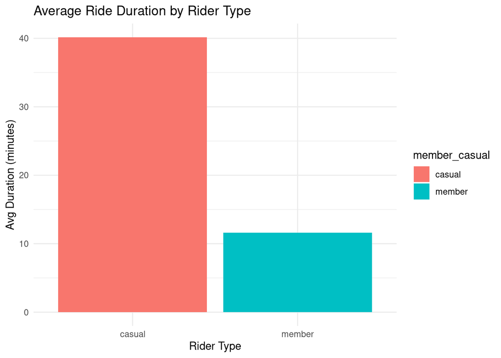

```r
# Bar chart: average ride duration
ggplot(avg_ride_length, aes(x = member_casual, y = avg_duration, fill = member_casual)) +
  geom_col() +
  labs(title = "Average Ride Duration by Rider Type",
       x = "Rider Type", y = "Avg Duration (minutes)") +
  theme_minimal()
```

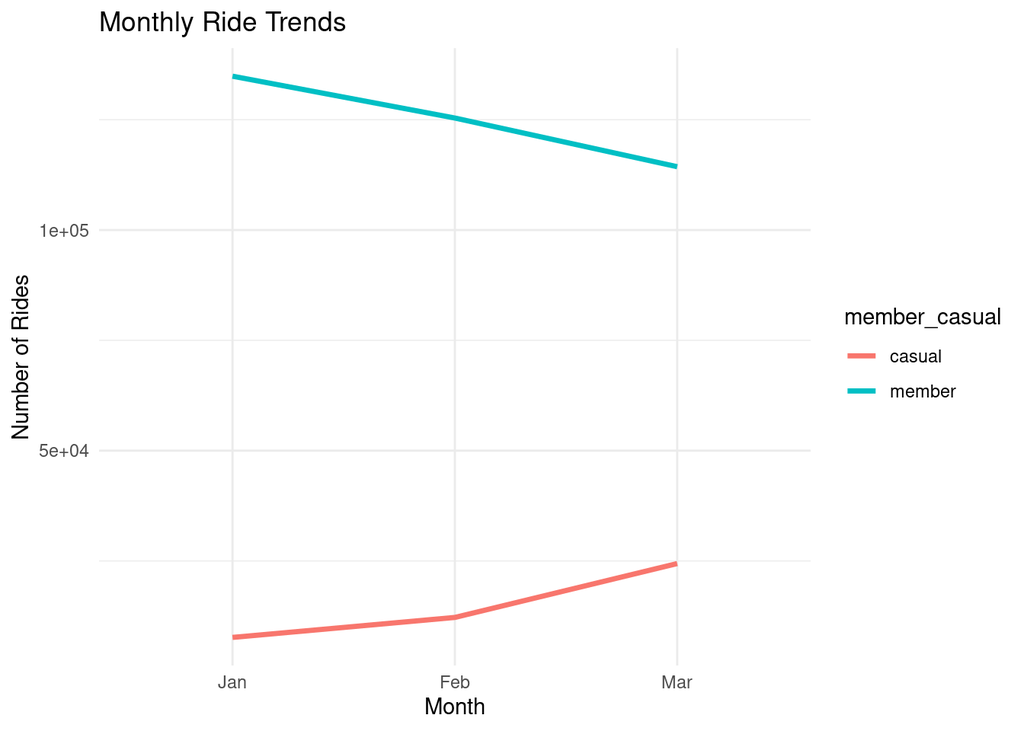

```r
# Line chart: monthly rides
ggplot(rides_by_month, aes(x = month, y = num_rides, color = member_casual, group = member_casual)) +
  geom_line(size=1.2) +
  labs(title = "Monthly Ride Trends",
       x = "Month", y = "Number of Rides") +
  theme_minimal()
```

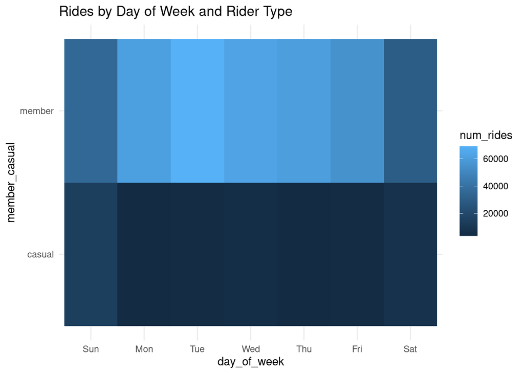

```r
# Heat map: rides by day of week and rider type
ggplot(rides_by_day, aes(x = day_of_week, y = member_casual, fill = num_rides)) +
  geom_tile() +
  labs(title = "Rides by Day of Week and Rider Type") +
  theme_minimal()
```

# Act

### Key Findings:

1. Casual riders take longer rides but ride less frequently.
2. Annual members ride more consistently, especially during weekdays (commuting patterns).
3. Casual riders are more active on weekends, suggesting leisure use.

### Recommendations:

1. **Target casual riders with weekday promotions** (commuter benefits).
2. **Offer membership discounts** for frequent weekend users.
3. **Use digital media campaigns** highlighting cost savings of memberships vs. single passes.

# Conclusion

This analysis shows clear differences in usage patterns. By leveraging these insights, Cyclistic can design targeted campaigns to **convert casual riders into annual members**.